# Practical Machine Learning Project

Chris Robertson

November 2019

This document is the final project for the Coursera “Practical Machine Learning” course. It was produced using RStudio’s Markdown and Knitr.

# Overview

Using devices such as Jawbone Up, Nike FuelBand, and Fitbit it is now possible to collect a large amount of data about personal activity relatively inexpensively. These type of devices are part of the quantified self movement – a group of enthusiasts who take measurements about themselves regularly to improve their health, to find patterns in their behavior, or because they are tech geeks.

One thing that people regularly do is quantify how much of a particular activity they do, but they rarely quantify how well they do it. In this project, the goal is to use data from accelerometers on the belt, forearm, arm, and dumbell of 6 participants. They were asked to perform barbell lifts correctly and incorrectly in 5 different ways.

The data consists of a training data and a test data (to be used to validate the selected model).

The goal of the project is to predict the manner in which they did the exercise. This is the “classe” variable in the training set. The projects uses any of the other variables to predict with.

Data source: The dataset used in this project is a courtesy of Velloso, E.; Bulling, A.; Gellersen, H.; Ugulino, W.; Fuks, H. Qualitative Activity Recognition of Weight Lifting Exercises. Proceedings of 4th International Conference in Cooperation with SIGCHI (Augmented Human ’13) . Stuttgart, Germany: ACM SIGCHI, 2013.

# Preparing Analytical Environment

Loading required packages.

```r
library(knitr)
library(caret)
library(rpart)
```

```r
library(rpart.plot)
library(rattle)
library(randomForest)
#Clean Data Environment
rm(list = ls())

#Runs Data Download Script
source("Download_Data.R")
```

## Load Data

After downloading the data from the data source, we can read the two csv files into two data frames.

```r
trainRaw <- read.csv("pml-training.csv")
testRaw <- read.csv("pml-testing.csv")
```

The training data set contains 19622 observations and 160 variables, while the testing data set contains 20 observations and 160 variables.

## Preprocessing Data

We remove the variables that contains missing values.

```r
trainRaw<- trainRaw[, colSums(is.na(trainRaw)) == 0]
testRaw <- testRaw[, colSums(is.na(testRaw)) == 0]
```

The first seven columns are removed as they will not be used in this analysis.

```r
trainData <- trainRaw[, -c(1:7)]
dim(trainRaw)
```

```
## [1] 19622    93
```

```r
dim(testRaw)
```

```
## [1] 20 60
```

Training data is then split into training and test sets.

```r
set.seed(1234)
inTrain <- createDataPartition(trainData$classe, p = 0.7, list = FALSE)
trainData <- trainData[inTrain, ]
testData <- trainData[-inTrain, ]
```

The final stage of the date preprossing is to remove columns that have near zero variance.

```r
near_zero_var <- nearZeroVar(trainData)
trainData <- trainData[, -near_zero_var]
testData  <- testData[, -near_zero_var]
dim(trainData)
```

```
## [1] 13737    53
```

```r
dim(testData)
```

```
## [1] 4123   53
```

We now have 53 variables with which we can build and test the model.

# Model Building

In this section we will use three different algorithms to predict the outcome.

1. Classification tree
2. Random forest
3. Gradient Boosted Model

## Classification Trees

We first generate the model and then we plot the classification tree as a dendogram.

[figure not shown]

```r
set.seed(12345)
modFitDecTree <- rpart(classe ~ ., data=trainData, method="class")
fancyRpartPlot(modFitDecTree)
```

Validation of the model “modFitDecTree” on the testData to find out how well it performs by looking at the accuracy variable.

```r
predictDecTree <- predict(modFitDecTree, newdata=testData, type="class")
confMatDecTree <- confusionMatrix(predictDecTree, testData$classe)
confMatDecTree
```

```
## Confusion Matrix and Statistics
##
##           Reference
## Prediction    A    B    C    D    E
##          A 1067  105    9   24    9
##          B   40  502   59   63   77
##          C   28   90  611  116   86
##          D   11   49   41  423   41
##          E   19   41   18   46  548
##
## Overall Statistics
##
##                Accuracy : 0.7642
##                  95% CI : (0.751, 0.7771)
##     No Information Rate : 0.2826
##     P-Value [Acc > NIR] : < 2.2e-16
##
##                   Kappa : 0.7015
##
##  Mcnemar's Test P-Value : < 2.2e-16
##
## Statistics by Class:
##
##                      Class: A Class: B Class: C Class: D Class: E
## Sensitivity            0.9159   0.6379   0.8279   0.6295   0.7201
## Specificity            0.9503   0.9284   0.9055   0.9589   0.9631
## Pos Pred Value         0.8789   0.6775   0.6563   0.7487   0.8155
## Neg Pred Value         0.9663   0.9157   0.9602   0.9300   0.9383
## Prevalence             0.2826   0.1909   0.1790   0.1630   0.1846
## Detection Rate         0.2588   0.1218   0.1482   0.1026   0.1329
## Detection Prevalence   0.2944   0.1797   0.2258   0.1370   0.1630
## Balanced Accuracy      0.9331   0.7831   0.8667   0.7942   0.8416
```

The accuracy rate of the model is low: 0.7642493 and therefore the out-of-sample-error is about 0.2357507.

## Random Forest

We then test the randon forest model. The first step is the creation of the random forest model itself. In this process we apply a 5 fold cross validation method.

```r
trainControl <- trainControl(method="cv", number=5)
model_RF <- train(classe~., data=trainData, method="rf", trControl=trainControl, verbose=FALSE)
print(model_RF)
```

```
## Random Forest
##
## 13737 samples
##    52 predictor
##     5 classes: 'A', 'B', 'C', 'D', 'E'
##
## No pre-processing
## Resampling: Cross-Validated (5 fold)
## Summary of sample sizes: 10990, 10989, 10990, 10990, 10989
## Resampling results across tuning parameters:
##
##   mtry  Accuracy   Kappa
##    2    0.9902455  0.9876597
##   27    0.9909732  0.9885809
##   52    0.9836934  0.9793700
##
## Accuracy was used to select the optimal model using the largest value.
## The final value used for the model was mtry = 27.
```

The plot of the random forest model showing the accuracy of random forest model by number of predictorsis as follows.

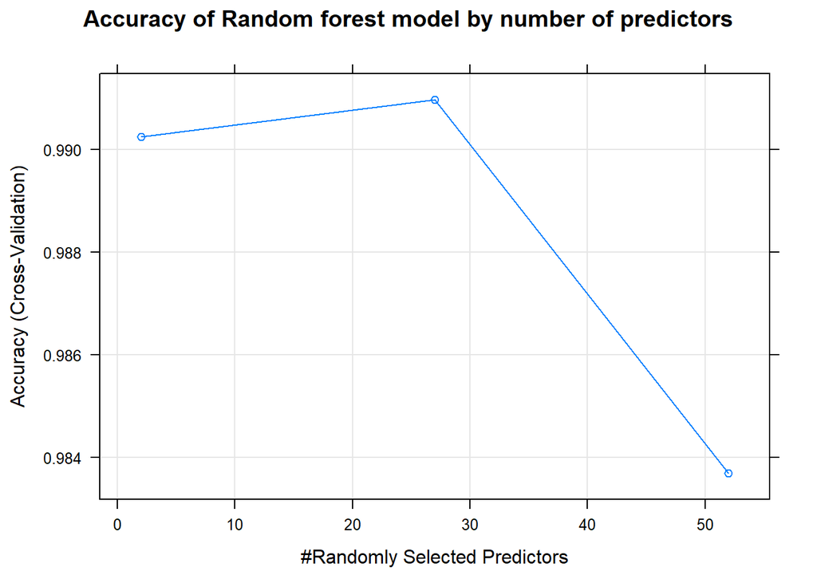

```r
plot(model_RF, main="Accuracy of Random forest model by number of predictors")
```

```r
trainpred <- predict(model_RF,newdata=testData)

confMatRF <- confusionMatrix(testData$classe,trainpred)
confMatRF
```

```
## Confusion Matrix and Statistics
##
##           Reference
## Prediction    A    B    C    D    E
##          A 1165    0    0    0    0
##          B    0  787    0    0    0
##          C    0    0  738    0    0
##          D    0    0    0  672    0
##          E    0    0    0    0  761
##
## Overall Statistics
##
##                Accuracy : 1
##                  95% CI : (0.9991, 1)
##     No Information Rate : 0.2826
##     P-Value [Acc > NIR] : < 2.2e-16
##
##                   Kappa : 1
##
##  Mcnemar's Test P-Value : NA
##
## Statistics by Class:
##
##                      Class: A Class: B Class: C Class: D Class: E
## Sensitivity            1.0000   1.0000    1.000    1.000   1.0000
## Specificity            1.0000   1.0000    1.000    1.000   1.0000
## Pos Pred Value         1.0000   1.0000    1.000    1.000   1.0000
## Neg Pred Value         1.0000   1.0000    1.000    1.000   1.0000
## Prevalence             0.2826   0.1909    0.179    0.163   0.1846
## Detection Rate         0.2826   0.1909    0.179    0.163   0.1846
## Detection Prevalence   0.2826   0.1909    0.179    0.163   0.1846
## Balanced Accuracy      1.0000   1.0000    1.000    1.000   1.0000
```

## Gradient Boosted Model

The last model we will test is the GBM model. In this process we apply the same 5 fold cross validation method we used for the random forest.

```r
model_GBM <- train(classe~., data=trainData, method="gbm", trControl=trainControl, verbose=FALSE)
print(model_GBM)
```

```
## Stochastic Gradient Boosting
##
## 13737 samples
##    52 predictor
##     5 classes: 'A', 'B', 'C', 'D', 'E'
##
## No pre-processing
## Resampling: Cross-Validated (5 fold)
## Summary of sample sizes: 10990, 10990, 10991, 10989, 10988
## Resampling results across tuning parameters:
##
##   interaction.depth  n.trees  Accuracy   Kappa
##   1                   50      0.7492892  0.6820283
##   1                  100      0.8207027  0.7731031
##   1                  150      0.8525150  0.8134065
##   2                   50      0.8565183  0.8181848
##   2                  100      0.9043454  0.8789625
##   2                  150      0.9307697  0.9124069
##   3                   50      0.8954638  0.8676710
##   3                  100      0.9403062  0.9244635
##   3                  150      0.9588700  0.9479582
##
## Tuning parameter 'shrinkage' was held constant at a value of 0.1
##
## Tuning parameter 'n.minobsinnode' was held constant at a value of 10
## Accuracy was used to select the optimal model using the largest value.
## The final values used for the model were n.trees = 150,
##  interaction.depth = 3, shrinkage = 0.1 and n.minobsinnode = 10.
```

```r
predictGBM <- predict(model_GBM, newdata=testData)
conmatrix_GBM <- confusionMatrix(predictGBM, testData$classe)
conmatrix_GBM
```

```
## Confusion Matrix and Statistics
##
##           Reference
## Prediction    A    B    C    D    E
##          A 1158   22    0    0    1
##          B    5  751   18    0    7
##          C    1   12  715   22    4
##          D    0    2    5  649    9
##          E    1    0    0    1  740
##
## Overall Statistics
##
##                Accuracy : 0.9733
##                  95% CI : (0.9679, 0.978)
##     No Information Rate : 0.2826
##     P-Value [Acc > NIR] : < 2.2e-16
##
##                   Kappa : 0.9663
##
##  Mcnemar's Test P-Value : NA
##
## Statistics by Class:
##
##                      Class: A Class: B Class: C Class: D Class: E
## Sensitivity            0.9940   0.9543   0.9688   0.9658   0.9724
## Specificity            0.9922   0.9910   0.9885   0.9954   0.9994
## Pos Pred Value         0.9805   0.9616   0.9483   0.9759   0.9973
## Neg Pred Value         0.9976   0.9892   0.9932   0.9933   0.9938
## Prevalence             0.2826   0.1909   0.1790   0.1630   0.1846
## Detection Rate         0.2809   0.1821   0.1734   0.1574   0.1795
## Detection Prevalence   0.2864   0.1894   0.1829   0.1613   0.1800
## Balanced Accuracy      0.9931   0.9726   0.9787   0.9806   0.9859
```

With GMB, we reach an accuracy of 0.9733204 using cross-validation with 5 steps and therefore the out-of-sample-error is about 0.0266796.

## Running In-sample test using most accurate model

By comparing the accuracy rate values of the three models, it is clear the the ‘Random Forest’ model is the winner with an accuracy of ~1. This is the model we will use on the validation data.

```r
Results <- predict(model_RF, newdata=testRaw)
Results
```

```
##  [1] B A B A A E D B A A B C B A E E A B B B
## Levels: A B C D E
```